**AML2019**

### Challenge 1

# House Pricing Prediction

*22<sup>th</sup> March 2019*

```python
!pip3 install --user 'xgboost'
!pip3 install --user 'keras'
!pip3 install --user 'h5py'
```

```
You are using pip version 18.0, however version 19.0.3 is available.
You are using pip version 18.0, however version 19.0.3 is available.
You are using pip version 18.0, however version 19.0.3 is available.
```

The first AML challenge for this year is adapted from the well-known '*Zillow's Home Value Prediction*' competition on Kaggle. In particular, given a dataset containing descriptions of homes on the US property market, your task is to make predictions on the selling price of as-yet unlisted properties. Developing a model which accurately fits the available training data while also generalising to unseen data-points is a multi-faceted challenge that involves a mixture of data exploration, pre-processing, model selection, and performance evaluation.

# Overview

Beyond simply producing a well-performing model for making predictions, in this challenge we would like you to start developing your skills as a machine learning scientist. In this regard, your notebook should be structured in such a way as to explore the five following tasks that are expected to be carried out whenever undertaking such a project. The description below each aspect should serve as a guide for your work, but you are strongly encouraged to also explore alternative options and directions. Thinking outside the box will always be rewarded in these challenges.

```python
import numpy as np
import pandas as pd
import matplotlib.pyplot as plt
import seaborn as sns
import tensorflow as tf
from tensorflow import keras
from tensorflow.keras import layers

from scipy.stats import norm
train = pd.read_csv('./challenge_data/train.csv')
test = pd.read_csv('./challenge_data/test.csv')
```

### 1. Data Exploration

The first broad component of your notebook should enable you to familiarise yourselves with the given data, an outline of which is given at the end of this challenge specification. Among others, this section should investigate:

- Data cleaning, e.g. treatment of categorial variables;
- Data visualisation;
- Computing descriptive statistics, e.g. correlation.
- etc.

```python
#drop the first id column
train = train.drop('Id' , axis=1)
test = test.drop('Id' , axis=1)

train.head()
```

|  | MSSubClass | MSZoning | LotFrontage | LotArea | Street | Alley | LotShape | LandContour | Utilities | LotConfig | ... | PoolArea | PoolQC | Fence | MiscFeature | MiscVal | MoSold | YrSold | SaleType | SaleCondition | SalePrice |
| --- | --- | --- | --- | --- | --- | --- | --- | --- | --- | --- | --- | --- | --- | --- | --- | --- | --- | --- | --- | --- | --- |
| 0 | 60 | RL | 65.0 | 8450 | Pave | NaN | Reg | Lvl | AllPub | Inside | ... | 0 | NaN | NaN | NaN | 0 | 2 | 2008 | WD | Normal | 208500 |
| 1 | 20 | RL | 80.0 | 9600 | Pave | NaN | Reg | Lvl | AllPub | FR2 | ... | 0 | NaN | NaN | NaN | 0 | 5 | 2007 | WD | Normal | 181500 |
| 2 | 60 | RL | 68.0 | 11250 | Pave | NaN | IR1 | Lvl | AllPub | Inside | ... | 0 | NaN | NaN | NaN | 0 | 9 | 2008 | WD | Normal | 223500 |
| 3 | 70 | RL | 60.0 | 9550 | Pave | NaN | IR1 | Lvl | AllPub | Corner | ... | 0 | NaN | NaN | NaN | 0 | 2 | 2006 | WD | Abnorml | 140000 |
| 4 | 60 | RL | 84.0 | 14260 | Pave | NaN | IR1 | Lvl | AllPub | FR2 | ... | 0 | NaN | NaN | NaN | 0 | 12 | 2008 | WD | Normal | 250000 |

5 rows × 80 columns

**COMMENTS :**

We do this because this column is useless, indeed there is already an indexing into the DataFrame.

```
count      1200.000000
mean     181414.628333
std       81070.908544
min       34900.000000
25%      129900.000000
50%      163700.000000
75%      214000.000000
max      755000.000000
Name: SalePrice, dtype: float64
```

```
{'boxes': [<matplotlib.lines.Line2D at 0x7fd9b2045e10>],
 'caps': [<matplotlib.lines.Line2D at 0x7fd9b1fd3860>,
 'fliers': [<matplotlib.lines.Line2D at 0x7fd9b1fe2518>],
 'means': [],
 'medians': [<matplotlib.lines.Line2D at 0x7fd9b1fe20f0>],
 'whiskers': [<matplotlib.lines.Line2D at 0x7fd9b2045f60>,
```

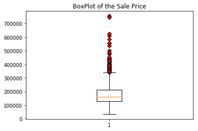

```python
#Getting informations on the price distribution

sale_price = train['SalePrice']

#Printing the value of the different parameters of this distribution
print(sale_price.describe())

#Plotting the box plot of the price distribution
plt.title('BoxPlot of the Sale Price')
red_diamond = dict(markerfacecolor='r', marker='D')
plt.boxplot(sale_price ,flierprops=red_diamond)
```

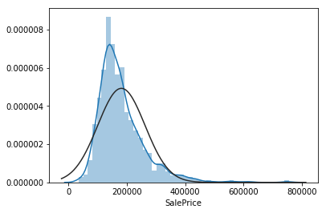

```python
#Plotting the distribution
sns.distplot(sale_price , fit=norm);

# Get the fitted parameters used by the function
(mu, sigma) = norm.fit(sale_price)
```

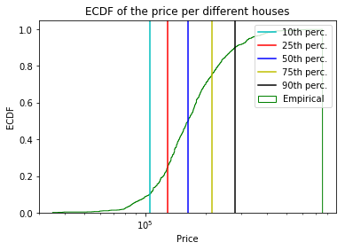

```python
fig, ax = plt.subplots()
listColor=['r', 'b' , 'y' , 'k' , 'c'] #List of color to make a better plot
# Plot the cumulative distribution
ax.hist(sale_price,sale_price.count(), density=True, histtype= 'step', cumulative=True, label='Empirical', color='green')

# Calculate and plot the 5 important percentiles
for i, quantile in enumerate([.1, 0.25, .5, .75, .9]):
    ax.axvline(sale_price.quantile(quantile), label='%.0fth perc.' % (quantile*100) , color=listColor[i-1])



ax.semilogx()
ax.set_title('ECDF of the price per different houses')
ax.set_xlabel('Price')
ax.set_ylabel('ECDF')
ax.legend()
plt.show()
```

**COMMENTS :**

According to the last 3 plots we can see that approximately 95% of the prices are between 30000 and 350000 and that 5% of the prices are above 350000 until a maximum of 755000. It’s pretty logical that there are less expensive houses than cheaper ones. Moreover the repartition seems pretty constant before going into the last 5% that are more expensive.

```
Text(0,0.5,'Price')
```

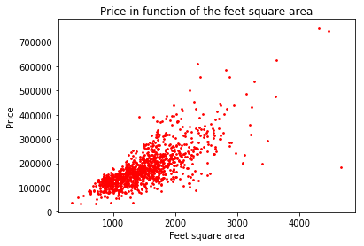

```python
plt.scatter(train['GrLivArea'], sale_price, s=3 , color='r')
plt.title('Price in function of the feet square area')
plt.xlabel('Feet square area')
plt.ylabel('Price')
```

**COMMENTS**

As we can see some house prices are to low for an high feet square area, so they do not represent well the sale price model, so we should suppress them while pre processing the data

```
Text(0,0.5,'Price')
```

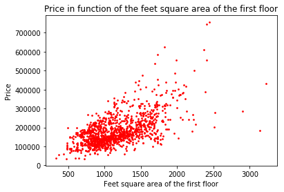

```python
plt.scatter(train['1stFlrSF'], sale_price, s=3 , color='r')
plt.title('Price in function of the feet square area of the first floor')
plt.xlabel('Feet square area of the first floor')
plt.ylabel('Price')
```

```
Text(0,0.5,'Price')
```

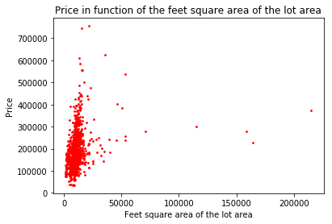

```python
plt.scatter(train['LotArea'], sale_price, s=3 , color='r')
plt.title('Price in function of the feet square area of the lot area')
plt.xlabel('Feet square area of the lot area')
plt.ylabel('Price')
```

**COMMENTS :**

Not really usefull as all houses seem to have the same lot square area but the price can change heavily.

```
Text(0,0.5,'Price')
```

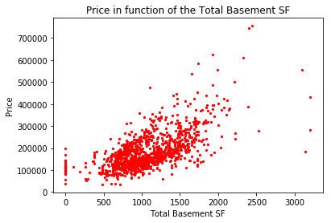

```python
#fig = plt.figure(1, figsize=(30,10 ))
plt.scatter(train['TotalBsmtSF'], sale_price, s=5, color='r')
plt.title('Price in function of the Total Basement SF')
plt.xlabel('Total Basement SF')
plt.ylabel('Price')
```

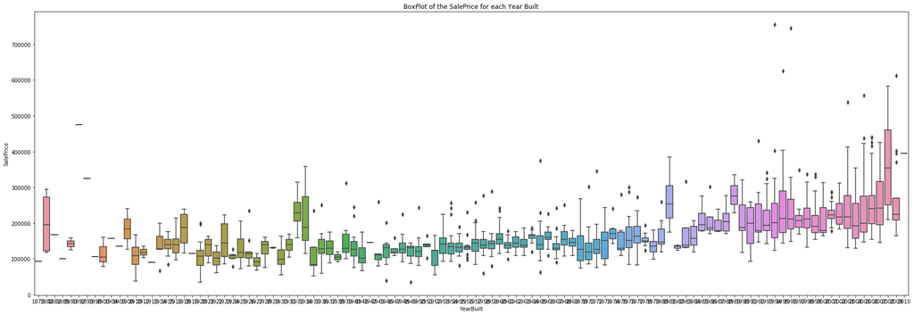

```python
fig = plt.figure(1, figsize=(30,10 ))
building_Year = train['YearBuilt']

plt.title('BoxPlot of the SalePrice for each Year Built')

sns.boxplot(building_Year , sale_price)
plt.show()
```

**COMMENTS :**

We observe that the prices are climbing with the time in terms of year built. Pretty logical because a house that is more recent is in general in a better shape and the price goes with this.

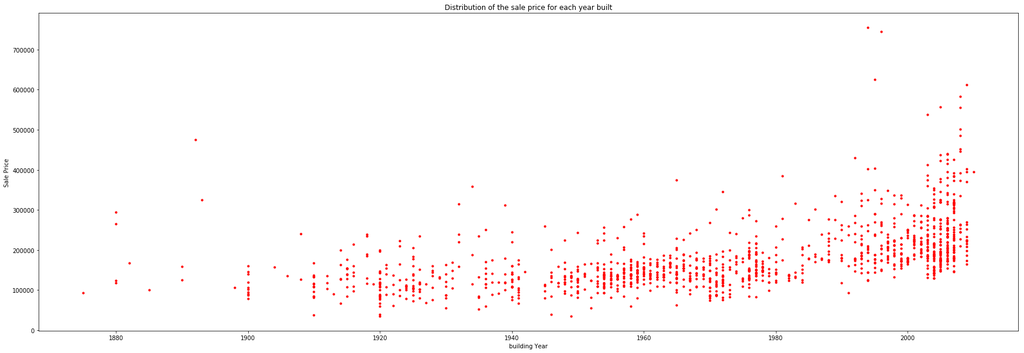

```python
fig = plt.figure(1, figsize=(30,10 ))
plt.title('Distribution of the sale price for each year built')
plt.xlabel('building Year')
plt.ylabel('Sale Price')
plt.scatter(building_Year, sale_price , s=10 ,color='r' )
```

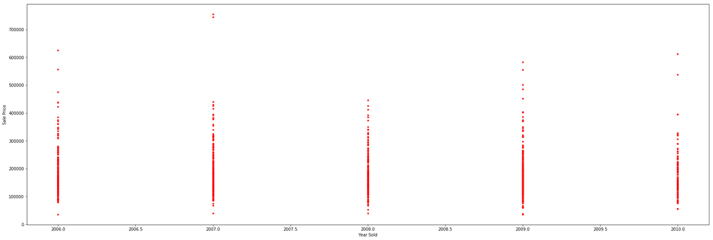

```python
selling_Year = train['YrSold']

fig = plt.figure(1, figsize=(30,10 ))
plt.xlabel('Year Sold')
plt.ylabel('Sale Price')
plt.scatter(selling_Year, sale_price , s=10 ,color='r' )
```

**COMMENTS :**

This graph shows us that the date of sold has no impact on the price. In real life we know that this is false, indeed the real estate field is currently growing in terms of price. We can explain this contradiction because the data is only on 5 years which is not enough to see a growth.

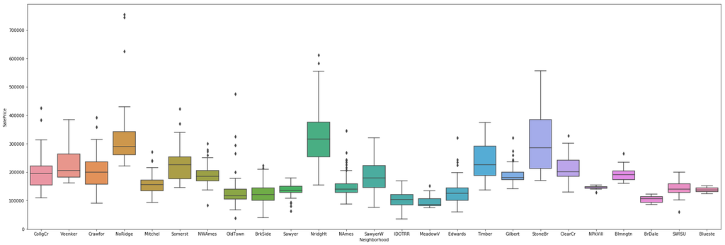

```python
neigbourhood_list = train['Neighborhood']

fig = plt.figure(1, figsize=(30,10))
sns.boxplot(neigbourhood_list, sale_price  )
```

**COMMENTS :**

This plot shows that the prices are not the same in every neighbourhood which is logical.

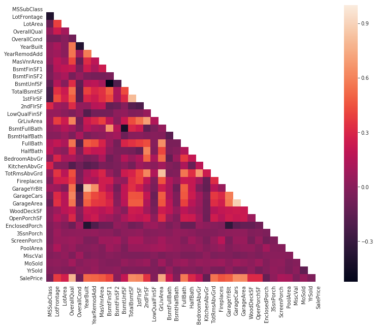

```python
fig = plt.figure(1, figsize=(15,10))
correlation_matrix = train.corr()
mask = np.zeros_like(correlation_matrix)
mask[np.triu_indices_from(mask)] = True
with sns.axes_style("white"):
    ax = sns.heatmap(correlation_matrix, mask=mask, square=True)
```

**COMMENTS**

We can see that some parameters have more related to the sale price ( which are brighter on the correlation)

```python
print (correlation_matrix['SalePrice'].sort_values(ascending=False)[:6], '\n')
print (correlation_matrix['SalePrice'].sort_values(ascending=False)[-5:])
```

```
SalePrice      1.000000
OverallQual    0.789142
GrLivArea      0.740379
TotalBsmtSF    0.641917
GarageCars     0.640961
GarageArea     0.623329
Name: SalePrice, dtype: float64

YrSold          -0.039841
MSSubClass      -0.075817
OverallCond     -0.082580
EnclosedPorch   -0.119790
KitchenAbvGr    -0.133544
Name: SalePrice, dtype: float64
```

**COMMENTS :**

As we see some parameters are very important and correlated with the price and others not very much, so we should focus on the important parameters.

### 2. Data Pre-processing

The previous step should give you a better understanding of which pre-processing is required for the data. This may include:

- Normalising and standardising the given data;
- Removing outliers;
- Carrying out feature selection, possibly using metrics derived from information theory;
- Handling missing information in the dataset;
- Augmenting the dataset with external information;
- Combining existing features.

#### 1.Handling missing informations

```
PoolQC          1196
MiscFeature     1153
Alley           1125
Fence            973
FireplaceQu      564
LotFrontage      210
GarageType        67
GarageFinish      67
GarageQual        67
GarageCond        67
GarageYrBlt       67
BsmtExposure      33
BsmtFinType2      33
BsmtCond          32
BsmtFinType1      32
BsmtQual          32
MasVnrArea         6
MasVnrType         6
RoofStyle          0
RoofMatl           0
dtype: int64
```

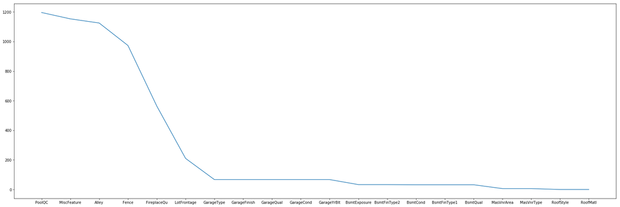

```python
#Finding which column has NaN value to replace them
fig = plt.figure(1, figsize=(30,10 ))
plt.plot(train.isnull().sum().sort_values(ascending= False)[:20])
print(train.isnull().sum().sort_values(ascending = False)[:20])
```

```python
features_drop = ['PoolQC','MiscFeature','Alley','Fence']
train = train.drop(features_drop, axis=1)
test = test.drop(features_drop, axis=1)

#in these columns  filling NaN by 0
for column in ['GarageType','GarageYrBlt','FireplaceQu','GarageFinish',
           'GarageQual','GarageCond','MasVnrType','MSSubClass' ,'BsmtFinType2' ,
               'BsmtExposure' , 'BsmtFinType1' , 'BsmtCond',
              'BsmtQual']:
    train[column] = train[column].fillna('0')
    test[column] = test[column].fillna('0')

#Filling the other columns with pd.interpolate
train['LotFrontage'] = train['LotFrontage'].fillna(train['LotFrontage'].median())
test['LotFrontage'] = test['LotFrontage'].fillna(test['LotFrontage'].median())

train['MasVnrArea'] = train['MasVnrArea'].fillna(train['MasVnrArea'].mode()[0])
train['MasVnrType'] = train['MasVnrType'].fillna(train['MasVnrType'].mode()[0])
test['MasVnrArea'] = test['MasVnrArea'].fillna(test['MasVnrArea'].mode()[0])
test['MasVnrType'] = test['MasVnrType'].fillna(test['MasVnrType'].mode()[0])



print(train.isnull().sum().sort_values(ascending = False)[:5])
```

```
SalePrice      0
Foundation     0
RoofMatl       0
Exterior1st    0
Exterior2nd    0
dtype: int64
```

```python
print(test.isnull().sum().sort_values(ascending = False)[:5])
```

```
Electrical       1
SaleCondition    0
Foundation       0
RoofMatl         0
Exterior1st      0
dtype: int64
```

```python
test['Electrical'] = test['Electrical'].fillna(test['Electrical'].mode()[0])
```

#### 2. Feature enginering and encoding categorical features

```python
#The aim of this code cell is to replace the categorical ie non numerical features to be able to use it in our ML programm
train_objs_num = len(train)

#First we concatenate the test and train
dataset = pd.concat(objs=[train, test], axis=0)

#This create a new data set where each non numerical attribute of a feature is now a new column where each row
#is equals one if it was the right attribute before
dataset = pd.get_dummies(dataset)

#Then splitting train and test
train = (dataset[:train_objs_num])
test = (dataset[train_objs_num:])

#Dropping the SalePrice axis
test = test.drop('SalePrice' , axis=1)

#Checking with still have non NaN values
print(test.isnull().sum().sort_values(ascending = False)[:5])
```

```
Utilities_NoSeWa       0
Exterior2nd_VinylSd    0
Exterior2nd_CBlock     0
Exterior2nd_CmentBd    0
Exterior2nd_HdBoard    0
dtype: int64
```

```python
print("Now the shape of our data set is " , train.shape)
print("Now the shape of our data test is " , test.shape)
```

```
Now the shape of our data set is  (1200, 384)
Now the shape of our data test is  (260, 383)
```

#### 3. Normalisation

```python
#After having delete null and non numerical values our aim is to standardizing the data to make our program more usefull to ML programm

#Normalising and standardising the given data by using the MinMaxScaler
from sklearn.preprocessing import MinMaxScaler


#Getting the list of column
col_train = list(train.columns)
col_train_bis = list(test.columns)


#Creating the matrixs based on the dataset to realise the normalization
mat_train = np.matrix(train)
mat_test  = np.matrix(test)
mat_y = np.array(train.SalePrice).reshape((train.shape[0],1))

#Realising the different fitting operations

#Fitting operation on the SalePrice to be able to find it back after
prepro_y = MinMaxScaler()
prepro_y.fit(mat_y)

#Fitting operation to normalize the train matrix
prepro = MinMaxScaler()
prepro.fit(mat_train)

#Fitting operation to normalize the test matrix
prepro_test = MinMaxScaler()
prepro_test.fit(mat_test)

#Realising the transformation from matrix to pd.df
train = pd.DataFrame(prepro.transform(mat_train),columns = col_train)
test  = pd.DataFrame(prepro_test.transform(mat_test),columns = col_train_bis)
```

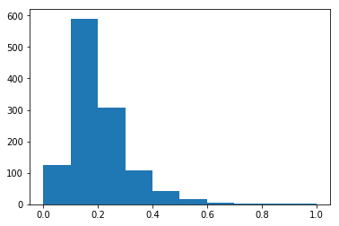

```python
#Showing some examples of the normalization
plt.hist(train.SalePrice)
```

#### 4. Removing Outliers

https://towardsdatascience.com/outlier-detection-with-isolation-forest-3d190448d45e

```python
#The aim of this cell is to delete outliers thanks to the API IsolationForest
from sklearn.ensemble import IsolationForest

print('The shape of our train set before removing outliers is ' , train.shape)

#Removing outliers thanks to isolation forest
clf = IsolationForest(max_samples = 100, random_state = 5)
clf.fit(train)

#List where if outlier value is = -1
outliers = clf.predict(train)

#reorganising our list
outliers = pd.DataFrame(outliers, columns = ['IsOutlier'])

#Delete the rows containing this outliers
train = train.iloc[outliers[outliers['IsOutlier'] == 1].index.values]


print("Number of Outliers:", outliers[outliers['IsOutlier'] == -1].shape[0])
print("Number of rows without outliers:", train.shape[0])

print('The shape of our train set after removing outliers is ' , train.shape)
```

```
The shape of our train set before removing outliers is  (1200, 384)
Number of Outliers: 120
Number of rows without outliers: 1080
The shape of our train set after removing outliers is  (1080, 384)
```

#### 5. Dropping useless columns

```python
#THe aim of this cell is to delete some useless columns
index_list = list(correlation_matrix['SalePrice'].sort_values(ascending=False)[-5:].index)
for i in range (len(index_list)):
    train.drop(index_list[i] , axis=1)
```

#### Augmenting the dataset with external information

#### Combining existing features

### 3. Model Selection

Perhaps the most important segment of this challenge involves the selection of a model that can successfully handle the given data and yield sensible predictions. Instead of focusing exclusively on your final chosen model, it is also important to share your thought process in this notebook by additionally describing alternative candidate models. There is a wealth of models to choose from, such as *decision trees*, *random forests*, *(Bayesian) neural networks*, *Gaussian processes*, *LASSO regression*, and so on. There are several factors which may influence your decision:

- What is the model's complexity?
- Is the model interpretable?
- Is the model capable of handling different data-types?
- Does the model return uncertainty estimates along with predictions?

An in-depth evaluation of competing models in view of this and other criteria will elevate the quality of your submission and earn you a higher grade.

```python
import math

#A function to calculate Root Mean Squared Logarithmic Error (RMSLE) ie to evaluate the performance of our model
def rmsle(y, y_pred):
    assert len(y) == len(y_pred)
    terms_to_sum = [(math.log(y_pred[i] + 1) - math.log(y[i] + 1)) ** 2.0 for i,pred in enumerate(y_pred)]
    return (sum(terms_to_sum) * (1.0/len(y))) ** 0.5
```

```python
#Splitting our train data into a test and a training part in order to determine the performane of our models
y = (train.SalePrice)
X = train.drop(['SalePrice'], axis=1)

from sklearn.model_selection import train_test_split
X_train, X_test, y_train, y_test = train_test_split(
                         X, y, random_state=20, test_size=.33)
```

#### 1. Neural Network

```python
#Building a neural network with tensorFlow and keras
def build_model():
    model = keras.Sequential([
    layers.Dense(200, activation=tf.nn.relu, input_shape=[len(X_train.keys())]),
    layers.Dense(100, activation=tf.nn.relu),
    layers.Dense(25, activation=tf.nn.relu),
    layers.Dense(12, activation=tf.nn.relu),
    layers.Dense(1)
  ])

    optimizer = tf.keras.optimizers.RMSprop(0.001)

    model.compile(loss='mean_squared_error',
                optimizer=optimizer,
                metrics=['mean_absolute_error', 'mean_squared_error'])
    return model
```

```python
#Showwing the characteristics
model = build_model()

model.summary()
```

```
_________________________________________________________________
Layer (type)                 Output Shape              Param #
=================================================================
dense (Dense)                (None, 200)               76800
_________________________________________________________________
dense_1 (Dense)              (None, 100)               20100
_________________________________________________________________
dense_2 (Dense)              (None, 25)                2525
_________________________________________________________________
dense_3 (Dense)              (None, 12)                312
_________________________________________________________________
dense_4 (Dense)              (None, 1)                 13
=================================================================
Total params: 99,750
Trainable params: 99,750
Non-trainable params: 0
_________________________________________________________________
```

```python
#Function from tensorflow to show the evolution of the number of epochs
class PrintDot(keras.callbacks.Callback):
    def on_epoch_end(self, epoch, logs):
        if epoch % 100 == 0: print('')
        print('.', end='')

EPOCHS = 100


#fitting the model to our data
history = model.fit(
  X_train, y_train,
  epochs=EPOCHS, validation_split = 0.1, verbose=0,
  callbacks=[PrintDot()])

hist = pd.DataFrame(history.history)
hist['epoch'] = history.epoch
hist.tail()
```

```
....................................................................................................
```

|  | loss | mean_absolute_error | mean_squared_error | val_loss | val_mean_absolute_error | val_mean_squared_error | epoch |
| --- | --- | --- | --- | --- | --- | --- | --- |
| 95 | 0.000189 | 0.009435 | 0.000189 | 0.001350 | 0.025619 | 0.001350 | 95 |
| 96 | 0.000187 | 0.009103 | 0.000187 | 0.001338 | 0.025671 | 0.001338 | 96 |
| 97 | 0.000160 | 0.008523 | 0.000160 | 0.001248 | 0.024928 | 0.001248 | 97 |
| 98 | 0.000125 | 0.007514 | 0.000125 | 0.001314 | 0.025315 | 0.001314 | 98 |
| 99 | 0.000196 | 0.009280 | 0.000196 | 0.001356 | 0.025245 | 0.001356 | 99 |

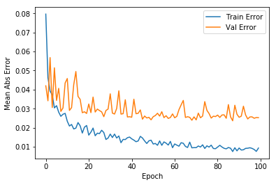

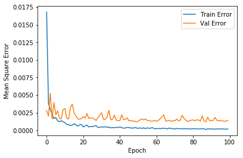

```python
#Plotting the Mean Abs error and Mean Squared error on our train and test data
def plot_history(history):
    hist = pd.DataFrame(history.history)
    hist['epoch'] = history.epoch

    plt.figure()
    plt.xlabel('Epoch')
    plt.ylabel('Mean Abs Error')
    plt.plot(hist['epoch'], hist['mean_absolute_error'],
           label='Train Error')
    plt.plot(hist['epoch'], hist['val_mean_absolute_error'],
           label = 'Val Error')
    plt.legend()

    plt.figure()
    plt.xlabel('Epoch')
    plt.ylabel('Mean Square Error')
    plt.plot(hist['epoch'], hist['mean_squared_error'],
           label='Train Error')
    plt.plot(hist['epoch'], hist['val_mean_squared_error'],
           label = 'Val Error')
    plt.legend()
    plt.show()


plot_history(history)
```

**COMMENTS** :

As we can see at 100 epochs our train error had validation error does not evolve anymore, so we don't need to do more than this number of iterations.

```python
#Computing the efficiency of our model
test_predictions = model.predict(X_test).flatten()

#Realising the inverse transform of the normalization done at the beginning
a = pd.DataFrame((y_test))
a = prepro_y.inverse_transform(a)

b= pd.DataFrame(test_predictions)
b= prepro_y.inverse_transform(b)

print(rmsle(np.array(a) ,np.array(b)))
```

```
0.1406247839232231
```

#### 2. Stochastic Gradient Descent Regression

```python
#Doing a regression using stochastic Gradient Descent from sklearn
from sklearn.linear_model import SGDRegressor

#Making the regression
clf = SGDRegressor(max_iter=100000, tol=1e-3)
clf.fit(X_train, y_train)


#Computing the predictions on the test
y_pred = clf.predict(X_test)

#Realising the inverse transform of the normalization done at the beginning
a = pd.DataFrame((y_test))
a = prepro_y.inverse_transform(a)

b= pd.DataFrame(y_pred)
b= prepro_y.inverse_transform(b)

print( "Our RMSLE is equals to " ,rmsle(np.array(a), np.array(b)))
```

```
Our RMSLE is equals to  0.16422900295900802
```

```python
from xgboost import XGBRegressor
XGBModel = XGBRegressor()
XGBModel.fit(X_train,y_train , verbose=False)

# Get the mean absolute error on the validation data :
y_pred = XGBModel.predict(X_test)

a = pd.DataFrame((y_test))
a = prepro_y.inverse_transform(a)

b= pd.DataFrame(y_pred)
b= prepro_y.inverse_transform(b)

print( "Our RMSLE is equals to " ,rmsle(np.array(a), np.array(b)))
```

```
Our RMSLE is equals to  0.12126217105470005
```

**COMMENTS:**

What is the model's complexity? Is the model interpretable? Is the model capable of handling different data-types? Does the model return uncertainty estimates along with predictions?

We will choose to work with the Neural Network in the next part.

Then all the model we have implemented above are not really understable. But however sklearn and xgboost don't provide a some human readable rules for instance. However, in the implementation of the Neural Network, we have the opportunities to customize more precisely the model with the activation function, the number of hidden layer and the number of neurons too. The two others API seems to work in a difficult way to be modified.

Furthermore, the neural network can work with floats and int and a large number of input, which is powerfull in our case where we hav more than 300 columns after data preprocessing.

Moreover, When there is lack of domain understanding for feature introspection, Deep Learning techniques outshines others as you have to worry less about feature engineering what is the case here.

Last, if we work in a BIG Data mind, we should think about more data and deep learning find its power and adnvatages over all algorithms in big data set. So this method would be extend easily.

### 4. Parameter Optimisation

Irrespective of your choice, it is highly likely that your model will have one or more parameters that require tuning. There are several techniques for carrying out such a procedure, including cross-validation, Bayesian optimisation, and several others. As before, an analysis into which parameter tuning technique best suits your model is expected before proceeding with the optimisation of your model.

**COMMENT/:**

Here, we choose to work on our neural network. So which parameters can we try to custom our model and make it work perfectly.

First of all, we should choose which architecture our model take (ie number of hidden layers, number of neurons, activation function etc...) , and the number of iterations too ( at the beginning I will chosse 100 epochs in order to go fast because it is computationally intensive)

Then, in a second part as I remarked before that our neural network is overfitting a bit much I will use cross validation. ross-validation is a powerful preventative measure against overfitting.

The idea is clever: Use your initial training data to generate multiple mini train-test splits. Use these splits to tune your model.In standard k-fold cross-validation, we partition the data into k subsets, called folds. Then, we iteratively train the algorithm on k-1 folds while using the remaining fold as the test set (called the “holdout fold”).

#### Activation function and Neural Network Architecture

**COMMENTS :**

First of all, we try to find some state of the art about linear regression in deep learning and regression problem and we found that we should use relu in the hidden layers (it is what is mostly used). Hence it avoids and rectifies vanishing gradient problem . Almost all deep learning Models use ReLu nowadays. For the last layer ie output layer we choose to leave the linear function because this is a regression problem.

In our regression problem as the data is not linearbly separable we must have some hidden layers. Here, we choose arbitraly to have 4 hiddenlayers.

Deciding the number of neurons in the hidden layers is a very important part. Both the number of hidden layers and the number of neurons in each of these hidden layers must be carefully considered.

Using too few neurons in the hidden layers will result in something called underfitting. Underfitting occurs when there are too few neurons in the hidden layers to create an enough complex model to represent our data set and the realtions within it

However, if we use too many neurons in the hidden layers can result in several problems. First, too many neurons in the hidden layers may result in overfitting. Overfitting occurs when the neural network has so much information processing capacity that the limited amount of information contained in the training set is not enough to train all of the neurons in the hidden layers. A second problem can occur even when the training data is sufficient. An inordinately large number of neurons in the hidden layers can increase the time it takes to train the network. Obviously, some compromise must be reached between too many and too few neurons in the hidden layers.

So, in our case we decide too try some combination of number of hidden layer and elect the most efficient one.

```python
architecture = [[200 , 150 , 80, 50] , [200 , 100 , 50, 12] , [100 , 80 , 50 ,12] , [300 , 150 , 100 , 80]]
```

```python
#Number of splits here : 5
n_split = 5
kf = KFold(n_splits=n_split) # Define the split
kf.get_n_splits(X) # returns the number of splitting iterations in the cross-validator

#Trying diffrent architectures
for number_neurons in architecture:
    print(number_neurons)
    #Building a neural network with tensorFlow and keras
    def build_model():
        model = keras.Sequential([
        layers.Dense(number_neurons[0], activation=tf.nn.relu, input_shape=[len(X_train.keys())]),
        layers.Dense(number_neurons[0], activation=tf.nn.relu),
        layers.Dense(number_neurons[0], activation=tf.nn.relu),
        layers.Dense(number_neurons[0], activation=tf.nn.relu),
        layers.Dense(1)
      ])

        optimizer = tf.keras.optimizers.RMSprop(0.001)

        model.compile(loss='mean_squared_error',
                    optimizer=optimizer,
                    metrics=['mean_absolute_error', 'mean_squared_error'])
        return model
    from sklearn.model_selection import KFold # import KFold


    #List of the different NN for each fold of the cross validation
    model1 = build_model()
    model2 = build_model()
    model3 = build_model()
    model4 = build_model()
    model5 = build_model()
    i=0

    list_model = [model1 , model2 , model3 , model4, model5]
    #for each fold creating a new model and after averaging all the results to get the final Sale Price
    for train_index, test_index in kf.split(X):
        #Getting the training and testing set form kfold function
        X_train = X.iloc[train_index]
        y_train = y.iloc[train_index]
        X_test = X.iloc[test_index]
        y_test=y.iloc[test_index]


        print('Model' , (i+1) , 'Building')
        list_model[i].fit( X_train, y_train,  epochs=EPOCHS, validation_split = 0.1, verbose=0,  callbacks=[PrintDot()])
        print()
        i+=1



    #Computing the efficiency of our model
    X_train, X_test, y_train, y_test = train_test_split( X, y ,test_size=.33)

    test_predictions = 0
    for model in list_model:
        test_predictions += model.predict(X_test).flatten()/n_split

    #Realising the inverse transform of the normalization done at the beginning

    a = pd.DataFrame((y_test))
    a = prepro_y.inverse_transform(a)

    b= pd.DataFrame(test_predictions)
    b= prepro_y.inverse_transform(b)

    rmsle_mean =(rmsle(np.array(a) ,np.array(b)))
    print(rmsle_mean)
```

```
[200, 150, 80, 50]
Model 1 Building

....................................................................................................
Model 2 Building

....................................................................................................
Model 3 Building

....................................................................................................
Model 4 Building

....................................................................................................
Model 5 Building

....................................................................................................
0.054157606434294514
[200, 100, 50, 12]
Model 1 Building

....................................................................................................
Model 2 Building

....................................................................................................
Model 3 Building

....................................................................................................
Model 4 Building

....................................................................................................
Model 5 Building

....................................................................................................
0.06815356619075125
[100, 80, 50, 12]
Model 1 Building

....................................................................................................
Model 2 Building

```

[output cut: 13 more lines]

```

....................................................................................................
Model 2 Building

....................................................................................................
Model 3 Building

....................................................................................................
Model 4 Building

....................................................................................................
Model 5 Building

....................................................................................................
0.06254526341910427
```

**COMMENTS:**

Furthermore, to avoid overfitting we decided to take a model which is the average of the five neural networks trained before with the K-fold cross validation to avoid overfitting which is the strong problem with the neural network especially on small training data.

```python
from sklearn.model_selection import KFold # import KFold

def build_model():
        model = keras.Sequential([
        layers.Dense(200, activation=tf.nn.relu, input_shape=[len(X_train.keys())]),
        layers.Dense(150, activation=tf.nn.relu),
        layers.Dense(80, activation=tf.nn.relu),
        layers.Dense(50, activation=tf.nn.relu),
        layers.Dense(1)
      ])

        optimizer = tf.keras.optimizers.RMSprop(0.001)

        model.compile(loss='mean_squared_error',
                    optimizer=optimizer,
                    metrics=['mean_absolute_error', 'mean_squared_error'])
        return model

#Number of splits
n_split = 5
kf = KFold(n_splits=n_split) # Define the split
kf.get_n_splits(X) # returns the number of splitting iterations in the cross-validator

#List of the different NN for each fold of the cross validation
model1 = build_model()
model2 = build_model()
model3 = build_model()
model4 = build_model()
model5 = build_model()

i=0

list_model = [model1 , model2 , model3 , model4 , model5]
for model in list_model:
     model = build_model()

    #for each fold creating a new model and after averaging all the results to get the final Sale Price
for train_index, test_index in kf.split(X):
    #Getting the training and testing set form kfold function
    X_train = X.iloc[train_index]
    y_train = y.iloc[train_index]
    X_test = X.iloc[test_index]
    y_test=y.iloc[test_index]


    #Fitting for our model
    print('Model' , (i+1) , 'Building')
    list_model[i].fit( X_train, y_train,  epochs=EPOCHS, validation_split = 0.1, verbose=0,  callbacks=[PrintDot()])


    i+=1



#Computing the efficiency of our model
X_train, X_test, y_train, y_test = train_test_split( X, y ,test_size=.33)

test_predictions = 0
for model in list_model:
    test_predictions += model.predict(X_test).flatten()/n_split


#Realising the inverse transform of the normalization done at the beginning



a = pd.DataFrame((y_test))
a = prepro_y.inverse_transform(a)

b= pd.DataFrame(test_predictions)
b= prepro_y.inverse_transform(b)

rmsle_mean =(rmsle(np.array(a) ,np.array(b)))
print(rmsle_mean)
```

```
Model 1 Building

....................................................................................................Model 2 Building

....................................................................................................Model 3 Building

....................................................................................................Model 4 Building

....................................................................................................Model 5 Building

....................................................................................................0.05191079415330902
```

### 5. Model Evaluation

Some form of pre-evaluation will inevitably be required in the preceding sections in order to both select an appropriate model and configure its parameters appropriately. In this final section, you may evaluate other aspects of the model such as:

- Assessing the running time of your model;
- Determining whether some aspects can be parallelised;
- Training the model with smaller subsets of the data.
- etc.

**N.B.** Please note that the items listed under each heading are neither exhaustive, nor are you expected to explore every given suggestion. Nonetheless, these should serve as a guideline for your work in both this and upcoming challenges. As always, you should use your intuition and understanding in order to decide which analysis best suits the assigned task.

#### Running time

```python
import time
start_time = time.time()

def build_model():
        model = keras.Sequential([
        layers.Dense(200, activation=tf.nn.relu, input_shape=[len(X_train.keys())]),
        layers.Dense(100, activation=tf.nn.relu),
        layers.Dense(50, activation=tf.nn.relu),
        layers.Dense(12, activation=tf.nn.relu),
        layers.Dense(1)
      ])

        optimizer = tf.keras.optimizers.RMSprop(0.001)

        model.compile(loss='mean_squared_error',
                    optimizer=optimizer,
                    metrics=['mean_absolute_error', 'mean_squared_error'])
        return model
#Number of splits
n_split = 5
kf = KFold(n_splits=n_split) # Define the split
kf.get_n_splits(X) # returns the number of splitting iterations in the cross-validator

#List of the different NN for each fold of the cross validation
model1 = build_model()
model2 = build_model()
model3 = build_model()
model4 = build_model()
model5 = build_model()

i=0

list_model = [model1 , model2 , model3 , model4 , model5]
for model in list_model:
     model = build_model()

    #for each fold creating a new model and after averaging all the results to get the final Sale Price
for train_index, test_index in kf.split(X):
    #Getting the training and testing set form kfold function
    X_train = X.iloc[train_index]
    y_train = y.iloc[train_index]
    X_test = X.iloc[test_index]
    y_test=y.iloc[test_index]


    #Fitting for our model
    print('Model' , (i+1) , 'Building')
    list_model[i].fit( X_train, y_train,  epochs=EPOCHS, validation_split = 0.1, verbose=0,  callbacks=[PrintDot()])


    i+=1



#Computing the efficiency of our model
X_train, X_test, y_train, y_test = train_test_split( X, y  ,test_size=.33)

test_predictions = 0
for model in list_model:
    test_predictions += model.predict(X_test).flatten()/n_split


#Realising the inverse transform of the normalization done at the beginning



a = pd.DataFrame((y_test))
a = prepro_y.inverse_transform(a)

b= pd.DataFrame(test_predictions)
b= prepro_y.inverse_transform(b)

rmsle_mean =(rmsle(np.array(a) ,np.array(b)))
print(rmsle_mean)

print("Temps d execution : %s secondes ---" % (time.time() - start_time))
```

```
Model 1 Building

....................................................................................................Model 2 Building

....................................................................................................Model 3 Building

....................................................................................................Model 4 Building

....................................................................................................Model 5 Building

....................................................................................................0.052831010530099046
Temps d execution : 71.43518567085266 secondes ---
```

**COMMENTS :**

So we see that our algorithm is a bit long, about 70secondes to train an predict on a quite little data set without precising the batch size. This is due to the fact that the more the data set is little, the less a Neural Network is very usefull because it will overfit fast to the training set. Furthermore this push us to do a combination of Neural Network, with Cross Validation, to aoid or reduce overfitting the more it is possible.

Indeed, if we have a bigger dataset I think we wouldn't need to do this king of cross validation but a smaller one.

However, if we precise the batch we can reduce heavily the computation time, as I will do in the next cell

```python
#Determining the computation time of our model for different batch size
import time
start_time = time.time()

def build_model():
        model = keras.Sequential([
        layers.Dense(200, activation=tf.nn.relu, input_shape=[len(X_train.keys())]),
        layers.Dense(100, activation=tf.nn.relu),
        layers.Dense(50, activation=tf.nn.relu),
        layers.Dense(12, activation=tf.nn.relu),
        layers.Dense(1)
      ])

        optimizer = tf.keras.optimizers.RMSprop(0.001)

        model.compile(loss='mean_squared_error',
                    optimizer=optimizer,
                    metrics=['mean_absolute_error', 'mean_squared_error'])
        return model
#Number of splits
n_split = 5
kf = KFold(n_splits=n_split) # Define the split
kf.get_n_splits(X) # returns the number of splitting iterations in the cross-validator

#List of the different NN for each fold of the cross validation
model1 = build_model()
model2 = build_model()
model3 = build_model()
model4 = build_model()
model5 = build_model()

batch_size_list= [ 100 ,200 , 300 , 500 , 800 , 1000]
time_list = []
rmsle_list =[]
for size in batch_size_list:
    start_time = time.time()
    i=0

    list_model = [model1 , model2 , model3 , model4 , model5]
    for model in list_model:
         model = build_model()

        #for each fold creating a new model and after averaging all the results to get the final Sale Price
    for train_index, test_index in kf.split(X):
        #Getting the training and testing set form kfold function
        X_train = X.iloc[train_index]
        y_train = y.iloc[train_index]
        X_test = X.iloc[test_index]
        y_test=y.iloc[test_index]


        #Fitting for our model
        print('Model' , (i+1) , 'Building')
        list_model[i].fit( X_train, y_train,  epochs=EPOCHS, batch_size= size , validation_split = 0.1, verbose=0,  callbacks=[PrintDot()])


        i+=1



    #Computing the efficiency of our model
    X_train, X_test, y_train, y_test = train_test_split( X, y  ,test_size=.33)

    test_predictions = 0
    for model in list_model:
        test_predictions += model.predict(X_test).flatten()/n_split


    #Realising the inverse transform of the normalization done at the beginning



    a = pd.DataFrame((y_test))
    a = prepro_y.inverse_transform(a)

    b= pd.DataFrame(test_predictions)
    b= prepro_y.inverse_transform(b)

    rmsle_mean =(rmsle(np.array(a) ,np.array(b)))
    rmsle_list.append(rmsle_mean)
    time_list.append (time.time() - start_time)
```

```
Model 1 Building

....................................................................................................Model 2 Building

....................................................................................................Model 3 Building

....................................................................................................Model 4 Building

....................................................................................................Model 5 Building

....................................................................................................Model 1 Building

....................................................................................................Model 2 Building

....................................................................................................Model 3 Building

....................................................................................................Model 4 Building

....................................................................................................Model 5 Building

....................................................................................................Model 1 Building

....................................................................................................Model 2 Building

....................................................................................................Model 3 Building

....................................................................................................Model 4 Building

....................................................................................................Model 5 Building

....................................................................................................Model 1 Building

....................................................................................................Model 2 Building

....................................................................................................Model 3 Building

....................................................................................................Model 4 Building

....................................................................................................Model 5 Building

....................................................................................................Model 1 Building

....................................................................................................Model 2 Building

....................................................................................................Model 3 Building

....................................................................................................Model 4 Building

....................................................................................................Model 5 Building

....................................................................................................Model 1 Building

....................................................................................................Model 2 Building

....................................................................................................Model 3 Building

....................................................................................................Model 4 Building

....................................................................................................Model 5 Building

....................................................................................................
```

```
Text(0,0.5,'Rmsle value')
```

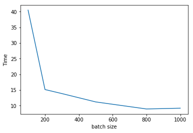

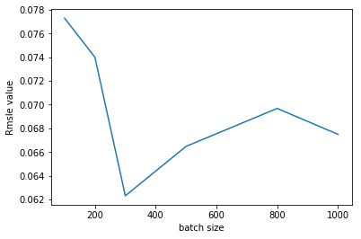

```python
#Plotting the time for different batch_size
plt.plot(batch_size_list , time_list)
plt.xlabel('batch size')
plt.ylabel('Time')

plt.figure()

plt.plot(batch_size_list ,rmsle_list)
plt.xlabel('batch size')
plt.ylabel('Rmsle value')
```

**COMMENTS:**

So as we can 300 appears to be a very good batch size. Indeed, the computation time is quite low and the rsmle value is into the lower values. This is a good compromise between efficiency and computation time

```python
start_time = time.time()


#Number of splits
n_split = 5
kf = KFold(n_splits=n_split) # Define the split
kf.get_n_splits(X) # returns the number of splitting iterations in the cross-validator

#List of the different NN for each fold of the cross validation
model1 = build_model()
model2 = build_model()
model3 = build_model()
model4 = build_model()
model5 = build_model()

time_list = []
rmsle_list =[]


i=0


list_model = [model1 , model2 , model3 , model4 , model5]
for model in list_model:
    model = build_model()

        #for each fold creating a new model and after averaging all the results to get the final Sale Price
for train_index, test_index in kf.split(X):
        #Getting the training and testing set form kfold function
    X_train = X.iloc[train_index]
    y_train = y.iloc[train_index]
    X_test = X.iloc[test_index]
    y_test=y.iloc[test_index]
        #Fitting for our model
    print('Model' , (i+1) , 'Building')
    list_model[i].fit( X_train, y_train,  epochs=EPOCHS, batch_size= 300 , validation_split = 0.1, verbose=0,  callbacks=[PrintDot()])

    i+=1



    #Computing the efficiency of our model
X_train, X_test, y_train, y_test = train_test_split( X, y  ,test_size=.33)

test_predictions = 0
for model in list_model:
    test_predictions += model.predict(X_test).flatten()/n_split


#Realising the inverse transform of the normalization done at the beginning

a = pd.DataFrame((y_test))
a = prepro_y.inverse_transform(a)

b= pd.DataFrame(test_predictions)
b= prepro_y.inverse_transform(b)

rmsle_mean =(rmsle(np.array(a) ,np.array(b)))



print('It take ' , abs(start_time- time.time()), 'and the Rmsle is ' , rmsle_mean)
```

```
Model 1 Building

....................................................................................................Model 2 Building

....................................................................................................Model 3 Building

....................................................................................................Model 4 Building

....................................................................................................Model 5 Building

....................................................................................................It take  14.942227363586426 and the Rmsle is  0.07340941200027284
```

```python
#The aim of this cell is to train our model on many subset from different size and to evaluate
#the performance on the rest of the training set to evaluate how our model is good with smaller data set
from sklearn.model_selection import KFold # import KFold

#List to train on different size of data
data_set_size = [0.01 , 0.1 , 0.2 , 0.3 , 0.4 , 0.5 , 0.6 , 0.7 , 0.8 , 0.9]

#List to get the rmsle for the different data size
rmsle_list = []
for size in data_set_size :
    from sklearn.model_selection import train_test_split
    X_subset, X_subtest, y_subset, y_subtest = train_test_split( X, y, random_state=20, test_size=size)


    #Number of splits
    n_split = 5
    kf = KFold(n_splits=n_split) # Define the split
    kf.get_n_splits(X_subset) # returns the number of splitting iterations in the cross-validator

    #List of the different NN for each fold of the cross validation
    model1 = build_model()
    model2 = build_model()
    model3 = build_model()
    model4 = build_model()
    model5 = build_model()


    list_model = [model1 , model2 , model3 , model4 , model5]
    i=0
    for model in list_model:
        model = build_model()

            #for each fold creating a new model and after averaging all the results to get the final Sale Price
    for train_index, test_index in kf.split(X_subset):
            #Getting the training and testing set form kfold function
        X_train = X.iloc[train_index]
        y_train = y.iloc[train_index]
        X_test = X.iloc[test_index]
        y_test=y.iloc[test_index]
            #Fitting for our model
        list_model[i].fit( X_train, y_train,  epochs=EPOCHS, batch_size= 200 , validation_split = 0.1, verbose=0,  callbacks=[PrintDot()])

        i+=1



    test_predictions = 0
    for model in list_model:
        test_predictions += model.predict(X_subtest).flatten()/n_split


    #Realising the inverse transform of the normalization done at the beginning

    a = pd.DataFrame((y_subtest))
    a = prepro_y.inverse_transform(a)

    b= pd.DataFrame(test_predictions)
    b= prepro_y.inverse_transform(b)

    rmsle_mean =(rmsle(np.array(a) ,np.array(b)))

    rmsle_list.append(rmsle_mean)

    print('The Rmsle is ' , rmsle_mean , 'for train size = ' , (1-size))
```

```
....................................................................................................
....................................................................................................
....................................................................................................
....................................................................................................
....................................................................................................The Rmsle is  0.05064987883205756 for train size =  0.99

....................................................................................................
....................................................................................................
....................................................................................................
....................................................................................................
....................................................................................................The Rmsle is  0.07759072429569526 for train size =  0.9

....................................................................................................
....................................................................................................
....................................................................................................
....................................................................................................
....................................................................................................The Rmsle is  0.08561511217226492 for train size =  0.8

....................................................................................................
....................................................................................................
....................................................................................................
....................................................................................................
....................................................................................................The Rmsle is  0.08946016476476124 for train size =  0.7

....................................................................................................
....................................................................................................
....................................................................................................
....................................................................................................
....................................................................................................The Rmsle is  0.10474240296175943 for train size =  0.6

....................................................................................................
....................................................................................................
....................................................................................................
....................................................................................................
....................................................................................................The Rmsle is  0.13171676144397287 for train size =  0.5

....................................................................................................
....................................................................................................
....................................................................................................
....................................................................................................
....................................................................................................The Rmsle is  0.1393976317306446 for train size =  0.4

....................................................................................................
....................................................................................................
....................................................................................................
....................................................................................................
....................................................................................................The Rmsle is  0.15916308855660255 for train size =  0.30000000000000004

....................................................................................................
....................................................................................................
....................................................................................................
....................................................................................................
....................................................................................................The Rmsle is  0.17672363910128147 for train size =  0.19999999999999996

....................................................................................................
....................................................................................................
....................................................................................................
....................................................................................................
....................................................................................................The Rmsle is  0.20610825006933509 for train size =  0.09999999999999998
```

```
Text(0.5,1,'Rmsle in function of the size of the training set')
```

[figure not shown]

```python
for size in data_set_size:
    size = 1- size
plt.plot(data_set_size , rmsle_list)
plt.xlabel("Train size")
plt.ylabel("RMSLE")
plt.title("Rmsle in function of the size of the training set")
```

**COMMENTS ON TRAINING ON SUBSET** :

As we can see the more we reduce our training set the more our previsions are not good. Indeed, it is what I explained befoe deep learning is done to be trained on large data set so here our model is not very tuned when we reduce the data set. Indeed, furthermore as we average the model on diferrent subset at the beginning thanks to K-fold we don't need to reduce our data set to train as we are already a bit doing it as each NN is trained on a subset

**COMMENTS ON A DISTRIBUTED PART:**

So we see that our model demands a lot of computation time so we may think about a way to parralelize and distribute the computation across several machines (with Spark for instance) and the data across several machines with HDFS for instance.

So if our data is big, let's simply use the HDFS storage system to split the data across th different machine. Here there is no need to do that as the data is quiet small.

No, let's think about how to distribute the computation work across several machines. One way to do it is to split our model in several machines, it can be split across multiple machines. For example, a single layer can be fit into the memory of a single machine and forward and backward propagation involves communication of output from one machine to another in a serial fashion. Furthermore, in our model which is a kind of combination of the same neural network but with different training sets we can just split the different training in the different machine. WIth this the computation time will reduce heavily. With this each worker will be in charge or training one model on a subset of the data and the final model will be the average of all (this is what i try to do but in a non distributed way) More generally, each machine can be responsible ofr training a certain part of the network, for instance each machine is responsible for training one layer but this is not quite effective.

```python
def build_model():
        model = keras.Sequential([
        layers.Dense(200, activation=tf.nn.relu, input_shape=[len(X_train.keys())]),
        layers.Dense(100, activation=tf.nn.relu),
        layers.Dense(50, activation=tf.nn.relu),
        layers.Dense(12, activation=tf.nn.relu),
        layers.Dense(1)
      ])

        optimizer = tf.keras.optimizers.RMSprop(0.001)

        model.compile(loss='mean_squared_error',
                    optimizer=optimizer,
                    metrics=['mean_absolute_error', 'mean_squared_error'])
        return model
#Number of splits
n_split = 5
kf = KFold(n_splits=n_split) # Define the split
kf.get_n_splits(X) # returns the number of splitting iterations in the cross-validator

#List of the different NN for each fold of the cross validation
model1 = build_model()
model2 = build_model()
model3 = build_model()
model4 = build_model()
model5 = build_model()

i=0

list_model = [model1 , model2 , model3 , model4 , model5]
for model in list_model:
     model = build_model()

    #for each fold creating a new model and after averaging all the results to get the final Sale Price
for train_index, test_index in kf.split(X):
    #Getting the training and testing set form kfold function
    X_train = X.iloc[train_index]
    y_train = y.iloc[train_index]
    X_test = X.iloc[test_index]
    y_test=y.iloc[test_index]


    #Fitting for our model
    print('Model' , (i+1) , 'Building')
    list_model[i].fit( X_train, y_train,  epochs=EPOCHS, validation_split = 0.1, verbose=0,  callbacks=[PrintDot()])


    i+=1





test_predictions = 0
for model in list_model:
    test_predictions += model.predict(test).flatten()/n_split


#Realising the inverse transform of the normalization done at the beginning



b= pd.DataFrame(test_predictions)
b= prepro_y.inverse_transform(b)
```

```
Model 1 Building

....................................................................................................Model 2 Building

....................................................................................................Model 3 Building

....................................................................................................Model 4 Building

....................................................................................................Model 5 Building

....................................................................................................
```

```python
#The aim of this cell is to create the submission

#Creating the index
final_result =pd.DataFrame ({'Id' : [i for i in range (1201,1461)]})

#Concataining the column of ID and result
final_result =  pd.concat([final_result, b], axis=1, sort=False)

#renaming the SalePrice column
final_result = final_result.rename(index=int, columns={0: "SalePrice"})
final_result.set_index('Id', inplace=True)


#Saving it to CSV
final_result.to_csv('sample_submission.csv')
```

[output not shown]

[output cut: 50 more lines]

## References

https://elitedatascience.com/overfitting-in-machine-learning#how-to-prevent [1]

https://scikit-learn.org/stable/modules/generated/sklearn.model_selection.KFold.html [2]

https://scikit-learn.org/stable/modules/generated/sklearn.preprocessing.MinMaxScaler.html [3]

https://www.tensorflow.org/tutorials/keras/basic_regression [4]

https://scikit-learn.org/stable/modules/generated/sklearn.linear_model.SGDClassifier.html [5]

https://pandas.pydata.org/pandas-docs/stable/reference/api/pandas.get_dummies.html [6]

https://xgboost.readthedocs.io/en/latest/python/python_api.html [7]

https://stanford.edu/~rezab/classes/cme323/S16/projects_reports/hedge_usmani.pdf [8]

## Submission Instructions

- The goal of this challenge is to construct a model for predicting house prices;
- Your submission will have two components:
  1. An **HTML version of your notebook** exploring the various modelling aspects described above;
  2. A CSV file containing your **final model's predictions on the given test data**. This file should contain a header and have the following format:

     ```
      Id,SalePrice
      1461,169000.1
      1462,187724.1233
      1463,175221
      etc.
     ```

     An example submission file has been provided in the data directory of the repository. A leaderboard for this challenge will be ranked using the root mean squared error between the logarithm of the predicted value and the logarithm of the observed sales price. Taking logs ensures that errors in predicting expensive houses and cheap houses will have a similar impact on the overall result;
- This exercise is due on **04/04/2019**.

## Dataset Description

#### * Files

- train.csv - The training dataset;
- test.csv - The test dataset;
- data_description.txt - Full description of each column.

#### * Attributes

A brief outline of the available attributes is given below:

- *SalePrice*: The property's sale price in dollars. This is the target variable that your model is intended to predict;
- *MSSubClass*: The building class;
- *MSZoning*: The general zoning classification;
- *LotFrontage*: Linear feet of street connected to property;
- *LotArea*: Lot size in square feet;
- *Street*: Type of road access;
- *Alley*: Type of alley access;
- *LotShape*: General shape of property;
- *LandContour*: Flatness of the property;
- *Utilities*: Type of utilities available;
- *LotConfig*: Lot configuration;
- *LandSlope*: Slope of property;
- *Neighborhood*: Physical locations within Ames city limits;
- *Condition1*: Proximity to main road or railroad;
- *Condition2*: Proximity to main road or railroad (if a second is present);
- *BldgType*: Type of dwelling;
- *HouseStyle*: Style of dwelling;
- *OverallQual*: Overall material and finish quality;
- *OverallCond*: Overall condition rating;
- *YearBuilt*: Original construction date;
- *YearRemodAdd*: Remodel date;
- *RoofStyle*: Type of roof;
- *RoofMatl*: Roof material;
- *Exterior1st*: Exterior covering on house;
- *Exterior2nd*: Exterior covering on house (if more than one material);
- *MasVnrType*: Masonry veneer type;
- *MasVnrArea*: Masonry veneer area in square feet;
- *ExterQualv*: Exterior material quality;
- *ExterCond*: Present condition of the material on the exterior;
- *Foundation*: Type of foundation;
- *BsmtQual*: Height of the basement;
- *BsmtCond*: General condition of the basement;
- *BsmtExposure*: Walkout or garden level basement walls;
- *BsmtFinType1*: Quality of basement finished area;
- *BsmtFinSF1*: Type 1 finished square feet;
- *BsmtFinType2*: Quality of second finished area (if present);
- *BsmtFinSF2*: Type 2 finished square feet;
- *BsmtUnfSF*: Unfinished square feet of basement area;
- *TotalBsmtSF*: Total square feet of basement area;
- *Heating*: Type of heating;
- *HeatingQC*: Heating quality and condition;
- *CentralAir*: Central air conditioning;
- *Electrical*: Electrical system;
- *1stFlrSF*: First Floor square feet;
- *2ndFlrSF*: Second floor square feet;
- *LowQualFinSF*: Low quality finished square feet (all floors);
- *GrLivArea*: Above grade (ground) living area square feet;
- *BsmtFullBath*: Basement full bathrooms;
- *BsmtHalfBath*: Basement half bathrooms;
- *FullBath*: Full bathrooms above grade;
- *HalfBath*: Half baths above grade;
- *Bedroom*: Number of bedrooms above basement level;
- *Kitchen*: Number of kitchens;
- *KitchenQual*: Kitchen quality;
- *TotRmsAbvGrd*: Total rooms above grade (does not include bathrooms);
- *Functional*: Home functionality rating;
- *Fireplaces*: Number of fireplaces;
- *FireplaceQu*: Fireplace quality;
- *GarageType*: Garage location;
- *GarageYrBlt*: Year garage was built;
- *GarageFinish*: Interior finish of the garage;
- *GarageCars*: Size of garage in car capacity;
- *GarageArea*: Size of garage in square feet;
- *GarageQual*: Garage quality;
- *GarageCond*: Garage condition;
- *PavedDrive*: Paved driveway;
- *WoodDeckSF*: Wood deck area in square feet;
- *OpenPorchSF*: Open porch area in square feet;
- *EnclosedPorch*: Enclosed porch area in square feet;
- *3SsnPorch*: Three season porch area in square feet;
- *ScreenPorch*: Screen porch area in square feet;
- *PoolArea*: Pool area in square feet;
- *PoolQC*: Pool quality;
- *Fence*: Fence quality;
- *MiscFeature*: Miscellaneous feature not covered in other categories;
- *MiscVal*: Value (in dollars) of miscellaneous feature;
- *MoSold*: Month sold;
- *YrSold*: Year sold;
- *SaleType*: Type of sale;
- *SaleCondition*: Condition of sale.